# Network Model Visualization

Understanding complicated network models through visualization

Sam Tyner  
@sctyner  
@sctyner

# Outline

- Motivation
- Working Example
- Model
- Visualizations
  - Static
  - Animation
  - Interactivity with `plotly`

# Motivating Example

Childhood vaccination - major public health concern

- [Vaccination animation](https://www.theguardian.com/society/ng-interactive/2015/feb/05/-sp-watch-how-measles-outbreak-spreads-when-kids-get-vaccinated)

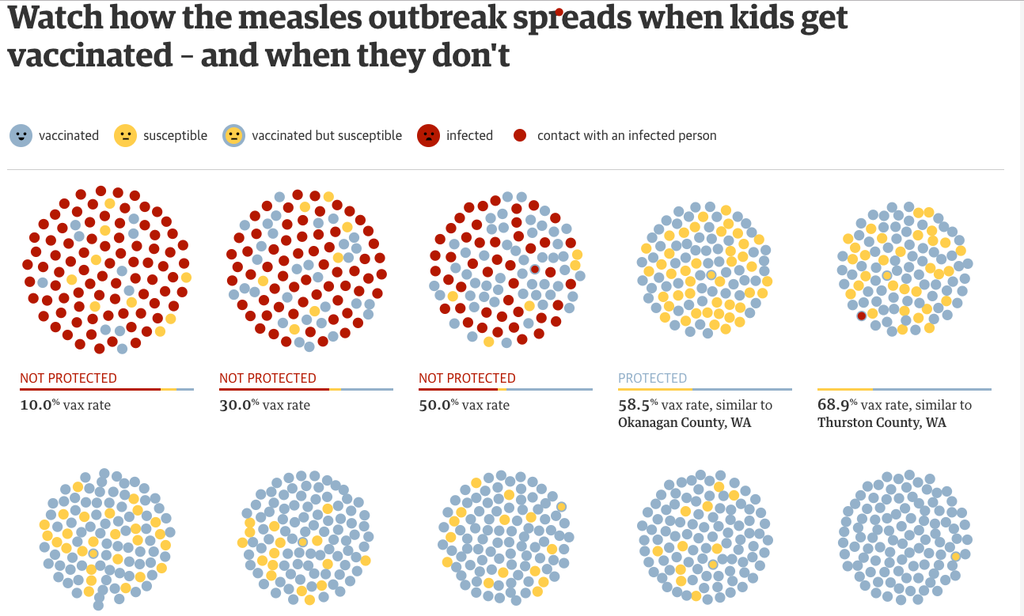

# Questions

Random interactions in animation aren’t realistic

- How do communities affect vaccination rate?
- How do communities affect spread of disease from outside source?
- What factors lead to unvaccinated children?
- Can communities be identified and targeted for immunization programs?

> Can network modeling answer these?

# Working Example

Another public health concern - underage drinking & smoking

> How do friendships influence drinking and smoking behavior in teenagers?

Steglich, Snijders & Pearson (2010) “Dynamic Networks and Behavior: Searating Selection from Influence”

# Data

From “Teenage Friends and Lifestyle Study” (Pearson & Mitchell (2000); Pearson & West (2003))

- Glasgow, Scotland, UK, Feb 1995 - Jan 1997
- Panel data - three waves - aged 12-13 to 14-15
- Each student lists up to 6 school friends
- Smoking & drinking behavior, other lifestyle variables collected
- 160 students in total, only 50 in [example data](https://www.stats.ox.ac.uk/~snijders/siena/)

# Model

- Want: to determine how friendships change risky behavior and vice versa over time
- Solution: stochastic actor-oriented models (SAOMs) for networks (Snijders 1996)
  - Stochastic because they model network change over time
  - Actor-oriented because actor-level covariates are incorporated into model parameters